# Programovanie pre dátovú vedu: projekt 1

# Zadanie

- Stručne predstavte dáta pomocou SQL-LIKE syntaxe a grafiky „grammar of graphics“. Môžete uviesť počet záznamov, počet atribútov, ich typy a charakteristiky ktoré sú potrebné k tomu, aby ste dokázali vašu hypotézu. Sú pôvodné atribúty použiteľné, alebo je nutné niektoré transformovať na nové ? (napríklad ak mám vzdialenosť a čas, môžem si vypočítať rýchlosť a tú použiť pre ďalšiu fázu), majú dáta hodnoty, ktoré významne vybočujú z priemeru? Má dátaset chýbajúce hodnoty? Ako s nimi budete zaobchádzať? Prečo?
- V treťom kroku si stanovte jednu hypotézu, ktoré je overiteľná lineárnym regresným modelom a potvrďte ju pomocou krížovej validácie vstupných dát. Pri programovaní nepoužívajte cykly a špeciálne sa zamerajte na centrálne tendencie a rozptyl parametrov β1 a β2.

# Načítanie knižníc a datasetu

```r
library(tidyverse)
library(patchwork)
library(reshape2)
#library(readxl)
```

```r
wages <- read_csv("Wages.csv")
#wages <- read_excel("Wages.xls", sheet = "WAGE2")
```

# Charakteristika dát

## Názvy stĺpcov

```r
data.frame(colnames(wages))
```

| colnames.wages. |
| --- |
| wage |
| hours |
| IQ |
| KWW |
| educ |
| exper |
| tenure |
| age |
| married |
| black |

[output cut: 7 more lines]

## Ukážka dát v datasete

```r
head(wages, 10)
```

| wage | hours | IQ | KWW | educ | exper | tenure | age | married | black | south | urban | sibs | brthord | meduc | feduc | lwage |
| --- | --- | --- | --- | --- | --- | --- | --- | --- | --- | --- | --- | --- | --- | --- | --- | --- |
| 769 | 40 | 93 | 35 | 12 | 11 | 2 | 31 | 1 | 0 | 0 | 1 | 1 | 2 | 8 | 8 | 6.645091 |
| 808 | 50 | 119 | 41 | 18 | 11 | 16 | 37 | 1 | 0 | 0 | 1 | 1 | . | 14 | 14 | 6.694562 |
| 825 | 40 | 108 | 46 | 14 | 11 | 9 | 33 | 1 | 0 | 0 | 1 | 1 | 2 | 14 | 14 | 6.715384 |
| 650 | 40 | 96 | 32 | 12 | 13 | 7 | 32 | 1 | 0 | 0 | 1 | 4 | 3 | 12 | 12 | 6.476973 |
| 562 | 40 | 74 | 27 | 11 | 14 | 5 | 34 | 1 | 0 | 0 | 1 | 10 | 6 | 6 | 11 | 6.331502 |
| 1400 | 40 | 116 | 43 | 16 | 14 | 2 | 35 | 1 | 1 | 0 | 1 | 1 | 2 | 8 | . | 7.244227 |
| 600 | 40 | 91 | 24 | 10 | 13 | 0 | 30 | 0 | 0 | 0 | 1 | 1 | 2 | 8 | 8 | 6.396930 |
| 1081 | 40 | 114 | 50 | 18 | 8 | 14 | 38 | 1 | 0 | 0 | 1 | 2 | 3 | 8 | . | 6.985642 |
| 1154 | 45 | 111 | 37 | 15 | 13 | 1 | 36 | 1 | 0 | 0 | 0 | 2 | 3 | 14 | 5 | 7.050990 |
| 1000 | 40 | 95 | 44 | 12 | 16 | 16 | 36 | 1 | 0 | 0 | 1 | 1 | 1 | 12 | 11 | 6.907755 |

## Počet riadkov, stĺpcov a typy stĺpcov

```r
nrow(wages)
```

```
[1] 935
```

```r
ncol(wages)
```

```
[1] 17
```

```r
spec(wages)
```

## Význam stĺpcov

1. wage monthly earnings
2. hours average weekly hours
3. IQ IQ score
4. KWW knowledge of world work score
5. educ years of education
6. exper years of work experience
7. tenure years with current employer
8. age age in years
9. married =1 if married
10. black =1 if black
11. south =1 if live in south
12. urban =1 if live in SMSA
13. sibs number of siblings
14. brthord birth order
15. meduc mother’s education
16. feduc father’s education
17. lwage natural log of wage

## Ošetrenie chýbajúcich hodnôt

V pôvodnom datasete boli chýbajúce hodnoty reprezentované bodkami, pre jednoduchšiu prácu sme bodky nahradili NA.

```r
wages[wages == "."] <- NA
wages
```

| wage | hours | IQ | KWW | educ | exper | tenure | age | married | black | south | urban | sibs | brthord | meduc | feduc | lwage |
| --- | --- | --- | --- | --- | --- | --- | --- | --- | --- | --- | --- | --- | --- | --- | --- | --- |
| 769 | 40 | 93 | 35 | 12 | 11 | 2 | 31 | 1 | 0 | 0 | 1 | 1 | 2 | 8 | 8 | 6.645091 |
| 808 | 50 | 119 | 41 | 18 | 11 | 16 | 37 | 1 | 0 | 0 | 1 | 1 | NA | 14 | 14 | 6.694562 |
| 825 | 40 | 108 | 46 | 14 | 11 | 9 | 33 | 1 | 0 | 0 | 1 | 1 | 2 | 14 | 14 | 6.715384 |
| 650 | 40 | 96 | 32 | 12 | 13 | 7 | 32 | 1 | 0 | 0 | 1 | 4 | 3 | 12 | 12 | 6.476973 |
| 562 | 40 | 74 | 27 | 11 | 14 | 5 | 34 | 1 | 0 | 0 | 1 | 10 | 6 | 6 | 11 | 6.331502 |
| 1400 | 40 | 116 | 43 | 16 | 14 | 2 | 35 | 1 | 1 | 0 | 1 | 1 | 2 | 8 | NA | 7.244227 |
| 600 | 40 | 91 | 24 | 10 | 13 | 0 | 30 | 0 | 0 | 0 | 1 | 1 | 2 | 8 | 8 | 6.396930 |
| 1081 | 40 | 114 | 50 | 18 | 8 | 14 | 38 | 1 | 0 | 0 | 1 | 2 | 3 | 8 | NA | 6.985642 |
| 1154 | 45 | 111 | 37 | 15 | 13 | 1 | 36 | 1 | 0 | 0 | 0 | 2 | 3 | 14 | 5 | 7.050990 |
| 1000 | 40 | 95 | 44 | 12 | 16 | 16 | 36 | 1 | 0 | 0 | 1 | 1 | 1 | 12 | 11 | 6.907755 |

[output cut: 925 more lines]

```r
sum(is.na(wages))
```

```
[1] 355
```

```r
na_count <-sapply(wages, function(x) sum(is.na(x)))
na_count <- data.frame(na_count)
na_count
```

|  | na_count |
| --- | --- |
| wage | 0 |
| hours | 0 |
| IQ | 0 |
| KWW | 0 |
| educ | 0 |
| exper | 0 |
| tenure | 0 |
| age | 0 |
| married | 0 |
| black | 0 |

[output cut: 7 more lines]

Chýbajúcich hodnôt je 355 a aj to len v stĺpcoch birth order, mother’s education a father’s education. Tieto chýbajúce hodnoty by nemali ovplyvňovať naše hypotézy.

## Základné charakteristiky dát

### wage

```r
summary(wages$wage)
```

```
   Min. 1st Qu.  Median    Mean 3rd Qu.    Max.
  115.0   669.0   905.0   957.9  1160.0  3078.0
```

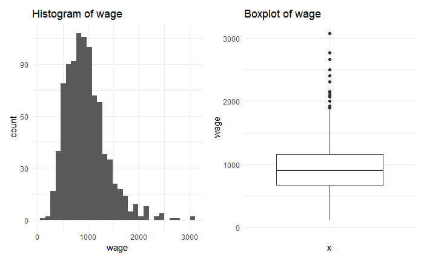

```r
wage_hist <- ggplot(wages) + ggtitle("Histogram of wage") + aes(x = wage) + geom_histogram() + theme_minimal()

wage_box <- ggplot(wages) + ggtitle("Boxplot of wage") + aes(x = "", y = wage) + geom_boxplot() + theme_minimal()

wage_hist + wage_box
```

### hours

```r
summary(wages$hours)
```

```
   Min. 1st Qu.  Median    Mean 3rd Qu.    Max.
  20.00   40.00   40.00   43.93   48.00   80.00
```

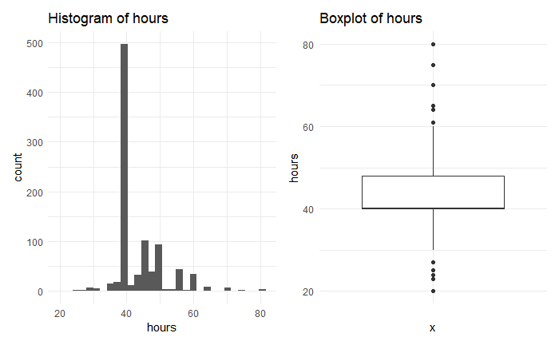

```r
hours_hist <- ggplot(wages) + ggtitle("Histogram of hours") + aes(x = hours) + geom_histogram() + theme_minimal()

hours_box <- ggplot(wages) + ggtitle("Boxplot of hours") + aes(x = "", y = hours) + geom_boxplot() + theme_minimal()

hours_hist + hours_box
```

### IQ

```r
summary(wages$IQ)
```

```
   Min. 1st Qu.  Median    Mean 3rd Qu.    Max.
   50.0    92.0   102.0   101.3   112.0   145.0
```

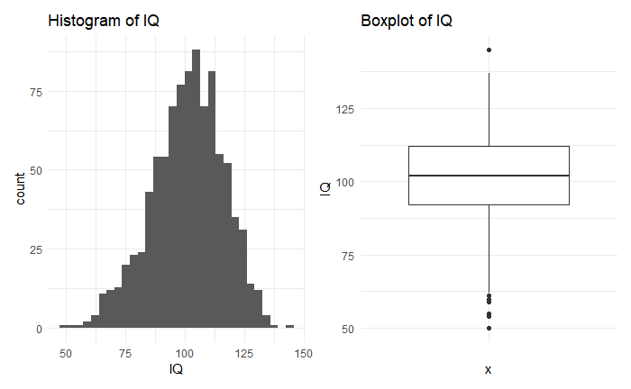

```r
iq_hist <- ggplot(wages) + ggtitle("Histogram of IQ") + aes(x = IQ) + geom_histogram() + theme_minimal()

iq_box <- ggplot(wages) + ggtitle("Boxplot of IQ") + aes(x = "", y = IQ) + geom_boxplot() + theme_minimal()

iq_hist + iq_box
```

### KWW

```r
summary(wages$KWW)
```

```
   Min. 1st Qu.  Median    Mean 3rd Qu.    Max.
  12.00   31.00   37.00   35.74   41.00   56.00
```

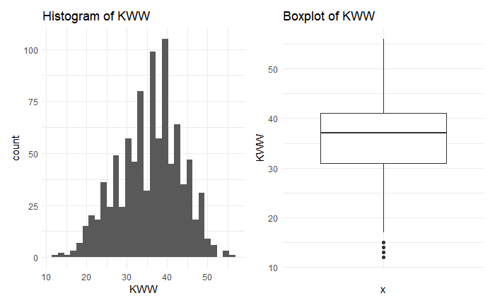

```r
kww_hist <- ggplot(wages) + ggtitle("Histogram of KWW") + aes(x = KWW) + geom_histogram() + theme_minimal()

kww_box <- ggplot(wages) + ggtitle("Boxplot of KWW") + aes(x = "", y = KWW) + geom_boxplot() + theme_minimal()

kww_hist + kww_box
```

### educ

```r
summary(wages$educ)
```

```
   Min. 1st Qu.  Median    Mean 3rd Qu.    Max.
   9.00   12.00   12.00   13.47   16.00   18.00
```

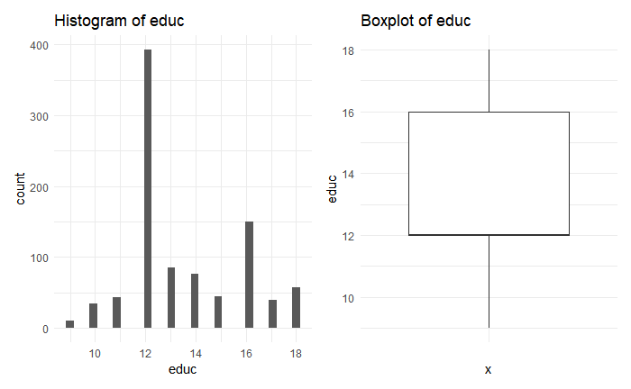

```r
educ_hist <- ggplot(wages) + ggtitle("Histogram of educ") + aes(x = educ) + geom_histogram() + theme_minimal()

educ_box <- ggplot(wages) + ggtitle("Boxplot of educ") + aes(x = "", y = educ) + geom_boxplot() + theme_minimal()

educ_hist + educ_box
```

### exper

```r
summary(wages$exper)
```

```
   Min. 1st Qu.  Median    Mean 3rd Qu.    Max.
   1.00    8.00   11.00   11.56   15.00   23.00
```

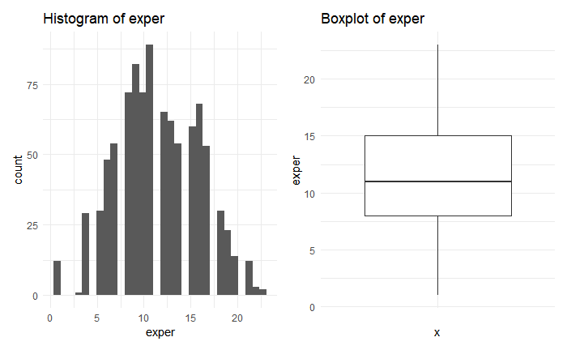

```r
exper_hist <- ggplot(wages) + ggtitle("Histogram of exper") + aes(x = exper) + geom_histogram() + theme_minimal()

exper_box <- ggplot(wages) + ggtitle("Boxplot of exper") + aes(x = "", y = exper) + geom_boxplot() + theme_minimal()

exper_hist + exper_box
```

### tenure

```r
summary(wages$tenure)
```

```
   Min. 1st Qu.  Median    Mean 3rd Qu.    Max.
  0.000   3.000   7.000   7.234  11.000  22.000
```

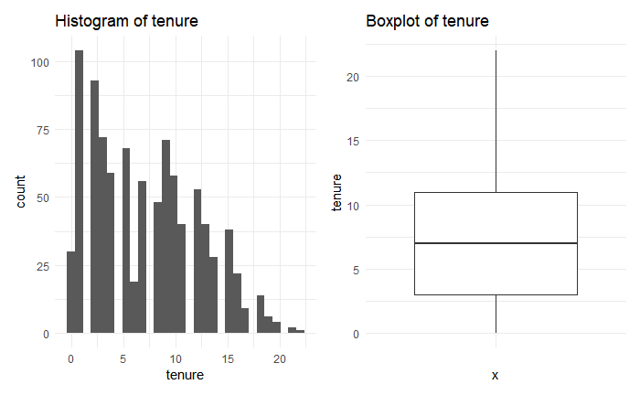

```r
tenure_hist <- ggplot(wages) + ggtitle("Histogram of tenure") + aes(x = tenure) + geom_histogram() + theme_minimal()

tenure_box <- ggplot(wages) + ggtitle("Boxplot of tenure") + aes(x = "", y = tenure) + geom_boxplot() + theme_minimal()

tenure_hist + tenure_box
```

### age

```r
summary(wages$age)
```

```
   Min. 1st Qu.  Median    Mean 3rd Qu.    Max.
  28.00   30.00   33.00   33.08   36.00   38.00
```

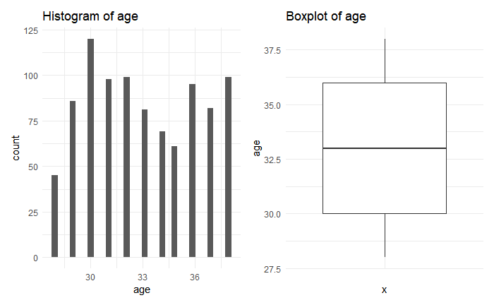

```r
age_hist <- ggplot(wages) + ggtitle("Histogram of age") + aes(x = age) + geom_histogram() + theme_minimal()

age_box <- ggplot(wages) + ggtitle("Boxplot of age") + aes(x = "", y = age) + geom_boxplot() + theme_minimal()

age_hist + age_box
```

## Dáta, ktoré významne vybočujú z priemeru

Takéto dáta možno vidieť pri stĺpcoch wages, hours, IQ a KWW. Keďže sa jedná o skutočných ľudí.

## Tranformácia atribútov

Uvažujúc, že stĺpec wages znamená mesačný zárobok a stĺpec hours znamená priemerný odrobený počet hodín za týždeň, môžeme vypočítať hodinovú mzdu pracovníka, ako podiel mesačnej mzdy a štvornásobku priemeru počtu hodín odrobených za týždeň.

```r
wages <- wages %>% mutate(hour_wage = (wage / (hours * 4)))
wages %>% select(wage, hours, hour_wage, educ) %>% head(10)
```

| wage | hours | hour_wage | educ |
| --- | --- | --- | --- |
| 769 | 40 | 4.806250 | 12 |
| 808 | 50 | 4.040000 | 18 |
| 825 | 40 | 5.156250 | 14 |
| 650 | 40 | 4.062500 | 12 |
| 562 | 40 | 3.512500 | 11 |
| 1400 | 40 | 8.750000 | 16 |
| 600 | 40 | 3.750000 | 10 |
| 1081 | 40 | 6.756250 | 18 |
| 1154 | 45 | 6.411111 | 15 |
| 1000 | 40 | 6.250000 | 12 |

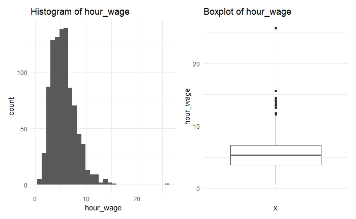

```r
hour_wage_hist <- ggplot(wages) + ggtitle("Histogram of hour_wage") + aes(x = hour_wage) + geom_histogram() + theme_minimal()

hour_wage_box <- ggplot(wages) + ggtitle("Boxplot of hour_wage") + aes(x = "", y = hour_wage) + geom_boxplot() + theme_minimal()

hour_wage_hist + hour_wage_box
```

```r
identify_outliers <- function(a) {
    lower = quantile(a, 0.25, na.rm = TRUE) - 1.5 * IQR(a);
    upper = quantile(a, 0.75, na.rm = TRUE) + 1.5 * IQR(a);

    outliers <- a[(a > upper) | (a < lower)];
    #count(outliers)
    #order(outliers)
    outliers
}

identify_outliers(wages$hour_wage)
```

```
 [1] 11.87222 14.43750 14.11667 15.62500 13.85500 12.02000 11.86875 13.51250 12.02000 13.51250 11.83846 12.91875 12.00000 13.35625 11.87222
[16] 13.51250 25.65000 11.87222 12.02500 14.42500
```

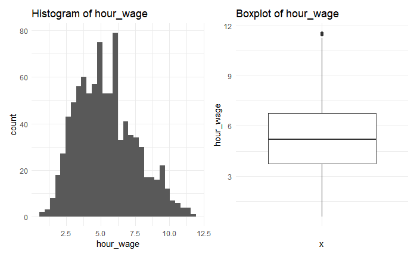

```r
remove_outliers <- function(a, b){
  lower = quantile(a, 0.25, na.rm = TRUE) - 1.5 * IQR(a);
  upper = quantile(a, 0.75, na.rm = TRUE) + 1.5 * IQR(a);
  standard <- b[!((a > upper) | (a < lower)), ]
  standard
}

standard = remove_outliers(wages$hour_wage, wages)
hour_wage_hist <- ggplot(standard) + ggtitle("Histogram of hour_wage") + aes(x = hour_wage) + geom_histogram() + theme_minimal()

hour_wage_box <- ggplot(standard) + ggtitle("Boxplot of hour_wage") + aes(x = "", y = hour_wage) + geom_boxplot() + theme_minimal()

hour_wage_hist + hour_wage_box
```

# Formulácia a štatistické overenie hypotéz

## Hypotézy

Existuje vzťah medzi výškou hodinovej mzdy a dĺžkou vzdelania?

$H_0$: Vzťah medzi výškou hodinovej mzdy a dĺžkou vzdelania **neexistuje**.

$H_1$: Vzťah medzi výškou hodinovej mzdy a dĺžkou vzdelania **existuje**.

## Lineárna regresia

```r
fit <- lm(hour_wage ~ educ, data = wages)
summary(fit)
```

```
Call:
lm(formula = hour_wage ~ educ, data = wages)

Residuals:
    Min      1Q  Median      3Q     Max
-5.3827 -1.6945 -0.2152  1.3215 20.2126

Coefficients:
            Estimate Std. Error t value Pr(>|t|)
(Intercept)  1.46745    0.48330   3.036  0.00246 **
educ         0.30538    0.03542   8.623  < 2e-16 ***
---
Signif. codes:  0 ‘***’ 0.001 ‘**’ 0.01 ‘*’ 0.05 ‘.’ 0.1 ‘ ’ 1

Residual standard error: 2.378 on 933 degrees of freedom
Multiple R-squared:  0.07381,   Adjusted R-squared:  0.07281
F-statistic: 74.35 on 1 and 933 DF,  p-value: < 2.2e-16
```

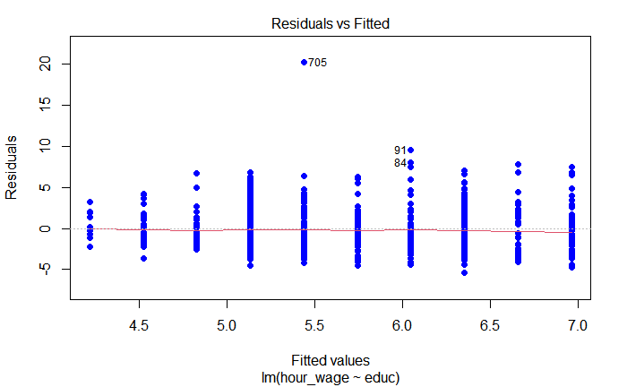

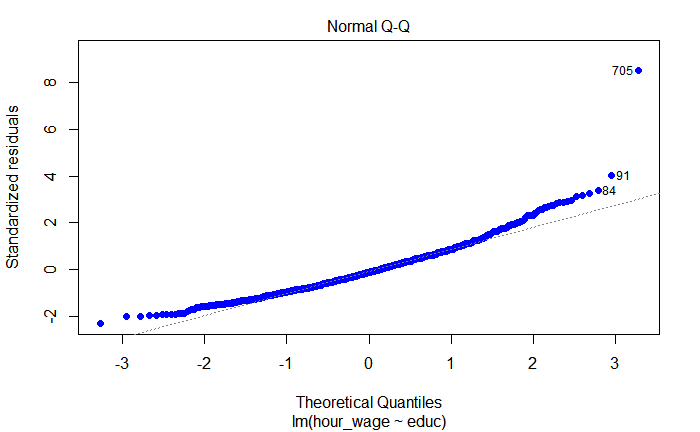

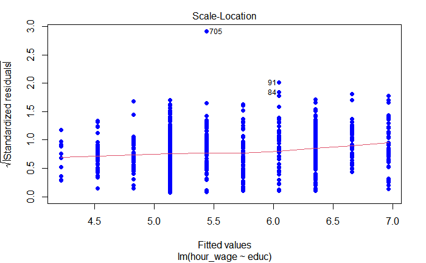

```r
plot(fit, pch = 16, col = "blue")
```

[figure not shown]

```r
NA
```

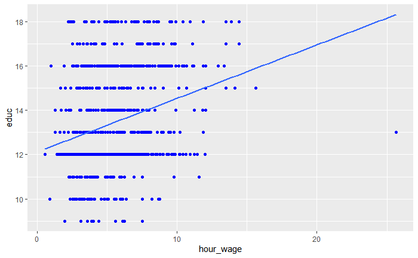

```r
ggplot(data = wages, aes(x = hour_wage, y = educ)) +
  geom_point(color='blue') +
  geom_smooth(method = "lm", se = FALSE)
```

```r
cormat <- round(cor(wages[, !names(wages) %in% c("brthord", "meduc",    "feduc")] ),3)
head(cormat)
```

```
        wage  hours     IQ   KWW   educ  exper tenure    age married  black  south  urban   sibs  lwage hour_wage
wage   1.000 -0.010  0.309 0.326  0.327  0.002  0.128  0.157   0.137 -0.211 -0.159  0.198 -0.159  0.953     0.931
hours -0.010  1.000  0.074 0.114  0.091 -0.062 -0.056  0.025   0.033 -0.108 -0.030  0.017 -0.050 -0.047    -0.318
IQ     0.309  0.074  1.000 0.414  0.516 -0.225  0.042 -0.044  -0.015 -0.388 -0.210  0.039 -0.285  0.315     0.265
KWW    0.326  0.114  0.414 1.000  0.388  0.017  0.141  0.393   0.090 -0.281 -0.094  0.098 -0.285  0.306     0.261
educ   0.327  0.091  0.516 0.388  1.000 -0.456 -0.036 -0.012  -0.059 -0.179 -0.097  0.072 -0.239  0.312     0.272
exper  0.002 -0.062 -0.225 0.017 -0.456  1.000  0.244  0.495   0.106  0.056  0.021 -0.047  0.064  0.021     0.018
```

```r
melted_cormat <- melt(cormat)
head(melted_cormat)
```

|  | Var1 | Var2 | value |
| --- | --- | --- | --- |
| 1 | wage | wage | 1.000 |
| 2 | hours | wage | -0.010 |
| 3 | IQ | wage | 0.309 |
| 4 | KWW | wage | 0.326 |
| 5 | educ | wage | 0.327 |
| 6 | exper | wage | 0.002 |

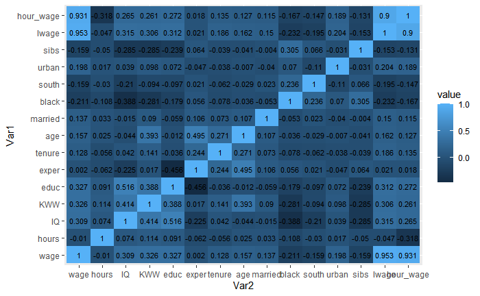

```r
ggplot(melted_cormat, aes(Var2, Var1, fill = value)) +
  geom_tile() +
  geom_text(aes(Var2, Var1, label = value), color = "black", size = 3)
```